# Exploration of receptors genes on Cheroni et al. samples

### 2. Data Upload

- Raw data produced by Salmon alignment
- Experimental design
- Gene annotation

#### 2.1 Read Count Matrix

```r
RawCounts <- read.table(params$CountFile, sep='\t', header=TRUE)
colSums(RawCounts[,-1])
##        Sample_KOLF2C1day25_S18177      Sample_KOLF2C1D25REP2_S18667
##                          51609909                          34372954
##        Sample_KOLF2C1day50_S18184      Sample_KOLF2C1D48REP2_S18677
##                          16505426                          18340209
##   Sample_S19785_KOLF2C1DAY100REP1   Sample_S19794_KOLF2C1DAY101REP2
##                          38535806                          36897320
##          Sample_MIFF1day25_S18178        Sample_MIFF1D25REP2_S18669
##                          47220949                          40956318
##          Sample_MIFF1day46_S18185        Sample_MIFF1D48REP2_S18679
##                          31856803                          29465545
##     Sample_S19781_MIFF1DAY100REP1     Sample_S19790_MIFF1DAY101REP2
##                          26819757                          33399922
##        Sample_S_3391Bday22_S18179      Sample_S_3391BD25REP2_S18668
##                          60053191                          34401356
##        Sample_S_3391Bday46_S18186      Sample_S_3391BD48REP2_S18678
##                          23921452                          38628297
##     Sample_S19784_3391BDAY100REP1     Sample_S19793_3391BDAY101REP2
##                          34652428                          33829523
##       Sample_A15461D25REP1_S18665       Sample_A15461D25REP2_S18666
##                          36553981                          38100908
##       Sample_A15461D48REP1_S18675       Sample_A15461D48REP2_S18676
##                          29518149                          25824797
##    Sample_S19779_A15461DAY100REP1    Sample_S19788_A15461DAY101REP2
##                          28574158                          29918356
##  Sample_S20430_A15461_DAY153_REP1 Sample_S20431_KOLF2C1_DAY153_REP1
##                          27249536                          17705141
##   Sample_S20432_3391B_DAY153_REP1   Sample_S20433_MIFF1_DAY149_REP1
##                          26906984                          22993777
##  Sample_S20434_A15461_DAY150_REP2 Sample_S20435_KOLF2C1_DAY150_REP2
##                          18833743                          21503329
##   Sample_S20436_3391B_DAY150_REP2   Sample_S20437_MIFF1_DAY150_REP2
##                          20870677                          20110136
##  Sample_S20438_A15461_DAY205_REP1 Sample_S20439_KOLF2C1_DAY205_REP1
##                          31606310                          21779953
##   Sample_S20440_3391B_DAY205_REP1   Sample_S20441_MIFF1_DAY205_REP1
##                          21214965                          22744354
## Sample_S20442_KOLF2C1_DAY193_REP2   Sample_S20443_3391B_DAY193_REP2
##                          29948152                          26832042
##   Sample_S20444_MIFF1_DAY193_REP2          Sample_S19798_A15461iPSC
##                          26901361                          25421514
##         Sample_S19797_KOLF2C1iPSC           Sample_S20260_3391BiPSC
##                          24903065                          27715530
##           Sample_S20259_MIFF1iPSC
##                          35139399
```

#### 2.2 Design Matrix

```r
Design <- read.table(params$DesignFile, sep='\t', header=TRUE)
str(Design)
## 'data.frame':    43 obs. of  13 variables:
##  $ InternaUniqueID: chr  "Sample_KOLF2C1day25_S18177" "Sample_KOLF2C1D25REP2_S18667" "Sample_KOLF2C1day50_S18184" "Sample_KOLF2C1D48REP2_S18677" ...
##  $ HRID           : chr  "Sample_KOLF2C1day25_S18177" "Sample_KOLF2C1D25REP2_S18667" "Sample_KOLF2C1day50_S18184" "Sample_KOLF2C1D48REP2_S18677" ...
##  $ SampleName     : chr  "S_KOLF2C1D25REP1" "S_KOLF2C1D25REP2" "S_KOLF2C1D50REP1" "S_KOLF2C1D48REP2" ...
##  $ Speciment      : chr  "Organoid" "Organoid" "Organoid" "Organoid" ...
##  $ Condition      : chr  "Day25" "Day25" "Day50" "Day50" ...
##  $ Group          : chr  "Org_25" "Org_25" "Org_50" "Org_50" ...
##  $ Line           : chr  "L_KOLF2C1" "L_KOLF2C1" "L_KOLF2C1" "L_KOLF2C1" ...
##  $ Sex            : chr  "M" "M" "M" "M" ...
##  $ DiffBatch      : int  1 2 2 5 5 6 1 2 4 5 ...
##  $ Seq            : chr  "PairedEnd" "PairedEnd" "PairedEnd" "PairedEnd" ...
##  $ RNASelection   : chr  "RiboZero" "RiboZero" "RiboZero" "RiboZero" ...
##  $ SeqPlatform    : chr  "Novaseq" "Novaseq" "Novaseq" "Novaseq" ...
##  $ Run            : int  180201 180420 180201 180420 180622 180622 180201 180420 180201 180420 ...
```

```r
as.data.frame(lapply(Design, factor)) %>%
  DT::datatable(class='hover', rownames=FALSE, caption='Sample identity and attributes',
                filter='top', escape=TRUE, extension='Buttons',
                options=list(pageLength=10, dom='Bfrtip',
                             columnDefs=list(list(className='dt-center', targets=c(5:(length(Design)-1)),
                                                  visible=FALSE)),  #as if indexing starts from 0
                             buttons=list(I('colvis'), c('csv', 'excel')))
                )
```

| InternaUniqueID | HRID | SampleName | Speciment | Condition | Group | Line | Sex | DiffBatch | Seq | RNASelection | SeqPlatform | Run |
| --- | --- | --- | --- | --- | --- | --- | --- | --- | --- | --- | --- | --- |
| Sample_KOLF2C1day25_S18177 | Sample_KOLF2C1day25_S18177 | S_KOLF2C1D25REP1 | Organoid | Day25 | Org_25 | L_KOLF2C1 | M | 1 | PairedEnd | RiboZero | Novaseq | 180201 |
| Sample_KOLF2C1D25REP2_S18667 | Sample_KOLF2C1D25REP2_S18667 | S_KOLF2C1D25REP2 | Organoid | Day25 | Org_25 | L_KOLF2C1 | M | 2 | PairedEnd | RiboZero | Novaseq | 180420 |
| Sample_KOLF2C1day50_S18184 | Sample_KOLF2C1day50_S18184 | S_KOLF2C1D50REP1 | Organoid | Day50 | Org_50 | L_KOLF2C1 | M | 2 | PairedEnd | RiboZero | Novaseq | 180201 |
| Sample_KOLF2C1D48REP2_S18677 | Sample_KOLF2C1D48REP2_S18677 | S_KOLF2C1D48REP2 | Organoid | Day50 | Org_50 | L_KOLF2C1 | M | 5 | PairedEnd | RiboZero | Novaseq | 180420 |
| Sample_S19785_KOLF2C1DAY100REP1 | Sample_S19785_KOLF2C1DAY100REP1 | S_KOLF2C1DAY100REP1 | Organoid | Day100 | Org_100 | L_KOLF2C1 | M | 5 | PairedEnd | RiboZero | Novaseq | 180622 |
| Sample_S19794_KOLF2C1DAY101REP2 | Sample_S19794_KOLF2C1DAY101REP2 | S_KOLF2C1DAY101REP2 | Organoid | Day100 | Org_100 | L_KOLF2C1 | M | 6 | PairedEnd | RiboZero | Novaseq | 180622 |
| Sample_MIFF1day25_S18178 | Sample_MIFF1day25_S18178 | S_MIFF1D25REP1 | Organoid | Day25 | Org_25 | L_MIFF1 | M | 1 | PairedEnd | RiboZero | Novaseq | 180201 |
| Sample_MIFF1D25REP2_S18669 | Sample_MIFF1D25REP2_S18669 | S_MIFF1D25REP2 | Organoid | Day25 | Org_25 | L_MIFF1 | M | 2 | PairedEnd | RiboZero | Novaseq | 180420 |
| Sample_MIFF1day46_S18185 | Sample_MIFF1day46_S18185 | S_MIFF1D46REP1 | Organoid | Day50 | Org_50 | L_MIFF1 | M | 4 | PairedEnd | RiboZero | Novaseq | 180201 |
| Sample_MIFF1D48REP2_S18679 | Sample_MIFF1D48REP2_S18679 | S_MIFF1D48REP2 | Organoid | Day50 | Org_50 | L_MIFF1 | M | 5 | PairedEnd | RiboZero | Novaseq | 180420 |

[output cut: 33 more lines]

**The dataset is structured in 58288 genes measured in 43 samples.**

#### 2.3 Gene Annotation

```r
if (is.null(params$GeneAnnotation)==FALSE){
  GeneAnnotation <- read.table(params$GeneAnnotationFile, sep='\t', header=TRUE)
  if(identical((RawCounts$Gene), GeneAnnotation$Gene)==FALSE){
    stop('ERROR! Gene order in count matrix and annotation matrix is not consistent. \n Please specify a data frame with the correct order.')
  }
}
```

```r
if ('hgnc_symbol' %in% colnames(GeneAnnotation)){
  GeneAnnotation <- dplyr::rename(GeneAnnotation, HGNCSymbol=hgnc_symbol)
}

if ('external_gene_name' %in% colnames(GeneAnnotation)){
  GeneAnnotation <- dplyr::rename(GeneAnnotation, GeneName=external_gene_name)
}

if ('gene_biotype' %in% colnames(GeneAnnotation)){
  GeneAnnotation <- dplyr::rename(GeneAnnotation, GeneBiotype=gene_biotype)
}

if ('chromosome_name' %in% colnames(GeneAnnotation)){
  GeneAnnotation <- dplyr::rename(GeneAnnotation, Chr=chromosome_name)
}

if ('start_position' %in% colnames(GeneAnnotation)){
  GeneAnnotation <- dplyr::rename(GeneAnnotation, Start=start_position)
}

if ('end_position' %in% colnames(GeneAnnotation)){
  GeneAnnotation <- dplyr::rename(GeneAnnotation, End=end_position)
}
```

### 3. Generation of Summarized Experiment

```r
if(identical(colnames(RawCounts)[-1], Design$HRID)==FALSE){
    stop('ERROR! Gene order in count matrix and annotation matrix is not consistent. \n
         Please specify a data frame with the correct order.')
  }
```

```r
SE <- createSE(countTable=RawCounts, sampleMeta=Design, geneMeta=GeneAnnotation,
               roundCounts=TRUE, showDuplicates=TRUE)
## The function removed 45 duplicated genes
##  [1] "ENSG00000002586.18_PAR_Y" "ENSG00000124333.15_PAR_Y"
##  [3] "ENSG00000124334.17_PAR_Y" "ENSG00000167393.17_PAR_Y"
##  [5] "ENSG00000168939.11_PAR_Y" "ENSG00000169084.13_PAR_Y"
##  [7] "ENSG00000169093.15_PAR_Y" "ENSG00000169100.13_PAR_Y"
##  [9] "ENSG00000178605.13_PAR_Y" "ENSG00000182162.10_PAR_Y"
## [11] "ENSG00000182378.13_PAR_Y" "ENSG00000182484.15_PAR_Y"
## [13] "ENSG00000185203.12_PAR_Y" "ENSG00000185291.11_PAR_Y"
## [15] "ENSG00000185960.13_PAR_Y" "ENSG00000196433.12_PAR_Y"
## [17] "ENSG00000197976.11_PAR_Y" "ENSG00000198223.16_PAR_Y"
## [19] "ENSG00000205755.11_PAR_Y" "ENSG00000214717.11_PAR_Y"
## [21] "ENSG00000223274.6_PAR_Y"  "ENSG00000223484.7_PAR_Y"
## [23] "ENSG00000223511.6_PAR_Y"  "ENSG00000223571.6_PAR_Y"
## [25] "ENSG00000223773.7_PAR_Y"  "ENSG00000225661.7_PAR_Y"
## [27] "ENSG00000226179.6_PAR_Y"  "ENSG00000227159.8_PAR_Y"
## [29] "ENSG00000228410.6_PAR_Y"  "ENSG00000228572.7_PAR_Y"
## [31] "ENSG00000229232.6_PAR_Y"  "ENSG00000230542.6_PAR_Y"
## [33] "ENSG00000234622.6_PAR_Y"  "ENSG00000234958.6_PAR_Y"
## [35] "ENSG00000236017.8_PAR_Y"  "ENSG00000236871.7_PAR_Y"
## [37] "ENSG00000237040.6_PAR_Y"  "ENSG00000237531.6_PAR_Y"
## [39] "ENSG00000237801.6_PAR_Y"  "ENSG00000265658.6_PAR_Y"
## [41] "ENSG00000270726.6_PAR_Y"  "ENSG00000275287.5_PAR_Y"
## [43] "ENSG00000277120.5_PAR_Y"  "ENSG00000280767.3_PAR_Y"
## [45] "ENSG00000281849.3_PAR_Y"
```

SE contains information about 58243 genes in 43 samples.

### 4. Removal of unwanted Biotypes

We decide to select here only protein-coding genes

```r
SE_Bio <- biotypeSelectSE(SE, lncRNA=FALSE, otherBios=NULL, showRemoved=TRUE)
## UPDATED library.size slot
## A total of 38425 rows out of 58243 were discarded, belonging to the following biotypes:
##
##           3prime_overlapping_ncRNA                      antisense_RNA
##                                 31                               5517
##      bidirectional_promoter_lncRNA                          IG_C_gene
##                                 19                                 14
##                    IG_C_pseudogene                          IG_D_gene
##                                  9                                 37
##                          IG_J_gene                    IG_J_pseudogene
##                                 18                                  3
##                      IG_pseudogene                          IG_V_gene
##                                  1                                144
##                    IG_V_pseudogene                            lincRNA
##                                188                               7493
##                       macro_lncRNA                              miRNA
##                                  1                               1879
##                           misc_RNA                            Mt_rRNA
##                               2212                                  2
##                            Mt_tRNA                         non_coding
##                                 22                                  3
##             polymorphic_pseudogene               processed_pseudogene
##                                 63                              10233
##               processed_transcript                         pseudogene
##                                543                                 18
##                           ribozyme                               rRNA
##                                  8                                543
##                             scaRNA                              scRNA
##                                 49                                  1
##                     sense_intronic                  sense_overlapping
##                                904                                189
##                             snoRNA                              snRNA
##                                943                               1900
##                               sRNA                                TEC
##                                  5                               1066
##                          TR_C_gene                          TR_D_gene
##                                  6                                  4
##                          TR_J_gene                    TR_J_pseudogene
##                                 79                                  4
##                          TR_V_gene                    TR_V_pseudogene
##                                108                                 30
##   transcribed_processed_pseudogene     transcribed_unitary_pseudogene
##                                462                                111
## transcribed_unprocessed_pseudogene    translated_processed_pseudogene
##                                828                                  2
##                 unitary_pseudogene             unprocessed_pseudogene
##                                 95                               2637
##                           vaultRNA
##                                  1
## A total of 19818 rows out of 58243 were kept, belonging to the following biotypes:
##
## protein_coding
##          19818

RemovedGenes <-  rowData(SE)[!(rownames(rowData(SE)) %in% rownames(rowData(SE_Bio))), ]
```

**After the gene selection based on biotypes, the dataset is structured in 19818 genes measured in 43 samples. 38425 have been discarded.**

### 5. Additional checks

#### 5.1 Check consistency in sample metadata for SE_bio

```r
if(! identical(names(assays(SE_Bio)$counts), rownames(colData(SE_Bio)))){
  stop('Inconsistencies in sample metadata for SE object')
  }

if(! identical(names(assays(SE_Bio)$counts), colData(SE_Bio)$HRID)){
  stop('Inconsistencies in sample metadata for SE object')
  }
```

#### 5.2 Gene Lenght

```r
GeneLength <- read.table(file='~/DataDir/ExternalData/BulkData/BenchmarkingOrganoids/GenecodeV27GeneLength.txt',
                         sep='\t', header=TRUE)
```

```r
SelLenght <- dplyr::left_join(as.data.frame(rowData(SE_Bio))[,1:3], GeneLength, by=c('Gene'='Gene'))
```

```r
if(identical(SelLenght$Gene, rowData(SE_Bio)$Gene)){
  rowData(SE_Bio)$GeneLength <- SelLenght$Length
  print('Gene Lengh information added to SE')
} else {
    print('Information on gene lenght is not compatible with SE object. Gene Lenght information not added to SE')
}
## [1] "Gene Lengh information added to SE"
```

### 6 Gene Filtering

#### 6.1 Setting gene filtering thresholds

```r
CpmFilt <- params$CpmFilt
if(is.numeric(CpmFilt)==FALSE){
  stop('ERROR! Cpm threshold for gene filtering has a non-numeric value')
}

SampleFilt <- ifelse(params$SampleFilt=='Default', dim(SE_Bio)[2]/2, params$SampleFilt)
if(is.numeric(SampleFilt)==FALSE){
  stop('ERROR! Sample threshold for gene filtering has a non-numeric value')
}
```

#### 6.2 Filter out low expressed genes

- Compute temporary cpm (without TMM normalization, not stored in SE)
- Filter out lowly-expressed genes

```r
SE_Bio$lib.size
##        Sample_KOLF2C1day25_S18177      Sample_KOLF2C1D25REP2_S18667
##                          35966674                          24130082
##        Sample_KOLF2C1day50_S18184      Sample_KOLF2C1D48REP2_S18677
##                           8946628                          12691980
##   Sample_S19785_KOLF2C1DAY100REP1   Sample_S19794_KOLF2C1DAY101REP2
##                          29092606                          27522714
##          Sample_MIFF1day25_S18178        Sample_MIFF1D25REP2_S18669
##                          29677523                          27411278
##          Sample_MIFF1day46_S18185        Sample_MIFF1D48REP2_S18679
##                          17982695                          18205132
##     Sample_S19781_MIFF1DAY100REP1     Sample_S19790_MIFF1DAY101REP2
##                          19886743                          25832968
##        Sample_S_3391Bday22_S18179      Sample_S_3391BD25REP2_S18668
##                          41468787                          22972771
##        Sample_S_3391Bday46_S18186      Sample_S_3391BD48REP2_S18678
##                          12161257                          23437065
##     Sample_S19784_3391BDAY100REP1     Sample_S19793_3391BDAY101REP2
##                          24695980                          25823667
##       Sample_A15461D25REP1_S18665       Sample_A15461D25REP2_S18666
##                          22730484                          25142562
##       Sample_A15461D48REP1_S18675       Sample_A15461D48REP2_S18676
##                          20868997                          18505787
##    Sample_S19779_A15461DAY100REP1    Sample_S19788_A15461DAY101REP2
##                          22659558                          23980057
##  Sample_S20430_A15461_DAY153_REP1 Sample_S20431_KOLF2C1_DAY153_REP1
##                          16681641                           5621105
##   Sample_S20432_3391B_DAY153_REP1   Sample_S20433_MIFF1_DAY149_REP1
##                          15688660                           8033761
##  Sample_S20434_A15461_DAY150_REP2 Sample_S20435_KOLF2C1_DAY150_REP2
##                           8488859                          13885616
##   Sample_S20436_3391B_DAY150_REP2   Sample_S20437_MIFF1_DAY150_REP2
##                          10806175                           9503179
##  Sample_S20438_A15461_DAY205_REP1 Sample_S20439_KOLF2C1_DAY205_REP1
##                          18505632                          12059447
##   Sample_S20440_3391B_DAY205_REP1   Sample_S20441_MIFF1_DAY205_REP1
##                          10981494                          12433247
## Sample_S20442_KOLF2C1_DAY193_REP2   Sample_S20443_3391B_DAY193_REP2
##                          17176679                          18144207
##   Sample_S20444_MIFF1_DAY193_REP2          Sample_S19798_A15461iPSC
##                          15599116                          20625329
##         Sample_S19797_KOLF2C1iPSC           Sample_S20260_3391BiPSC
##                          18616726                          20478866
##           Sample_S20259_MIFF1iPSC
##                          23226563
SE_Filt <- filterSE(SE_Bio, cpmTh=CpmFilt, sampleTh=SampleFilt)
## UPDATED library.size slot
#$lib.size
```

#### 6.3 Normalize

- Re-calculate library size and calculate TMM
- Calculate cpm and logcpm (with normalization) and store in SE_Filt
- Calculate Fpkm and logfpkm

```r
SE_Filt <- normTmmSE(SE_Filt, useNormFactors=TRUE, priorCount=0.25)
## Warning in normTmmSE(SE_Filt, useNormFactors = TRUE, priorCount = 0.25): The
## following colData columns will be recomputed: lib.size

#cpm and logcpm are calculated by normTmmSE

assays(SE_Filt)$fpkm <- edgeR::rpkm(SE_Filt, normalized.lib.sizes = TRUE, gene.length=rowData(SE_Filt)$GeneLength)
assays(SE_Filt)$logfpkm <- edgeR::rpkm(SE_Filt, normalized.lib.sizes = TRUE, gene.length=rowData(SE_Filt)$GeneLength,
                                  log=TRUE, prior.count=0.25)
```

**After filtering out lowly-expressed genes, the dataset is structured in 16638 genes measured in 43 samples.**

### 7. Heatmaps: exploration of receptors

#### 7.1 Preprocessing

##### 7.1.1 Gene name as row names

For the downstream interrogation, it become useful to have the gene names as SE row names, that are used by sechm for selecting genes. I also have to discard genes with duplicated gene names.

```r
rownames(SE_Filt) <- rowData(SE_Filt)$GeneName
SE_Filt <- SE_Filt[!duplicated(rownames(SE_Filt)), ]
```

##### 7.1.2 Calculate the fold-change

I use a function from SEtools to calculate the fold-change compared to the controls. This is done on logcpm.

```r
Day0 <- as.vector(which(SE_Filt$Condition=='Day0'))
SE_Filt <- SEtools::log2FC(SE_Filt, fromAssay='logcpm', controls=Day0, isLog=TRUE, toAssay='log2FC')
```

##### 7.1.3 Define the color annotation

```r
metadata(SE_Filt)$anno_colors <- list(Condition = c("Day0" = "#ffff3f", "Day25" = "#eeef20", "Day50" = "#dddf00", "Day100" = "#d4d700", "Day150" = "#bfd200", "Day200" = "#aacc00"), Sex = c("F" = "#f4978e", "M" = "#277da1"))
```

#### 7.2 Upload gene signature

```r
GS <- read.table(file = '~/DataDir/ExternalData/Receptors/EndocrineKeyGenes.txt',
                         sep='\t', header=TRUE)
```

```r
as.data.frame(GS) %>%
  DT::datatable(class='hover', rownames=FALSE, caption='Hormonal receptors',
                filter='top', escape=TRUE, extension='Buttons',
                options=list(pageLength=10, dom='Bfrtip',
                             buttons=list(I('colvis'), c('csv', 'excel')))
                )
```

| GeneName | Signature |
| --- | --- |
| THRB | THY |
| THRA | THY |
| THRAP3 | THY |
| DIO1 | THY |
| DIO2 | THY |
| DIO3 | THY |
| SLC16A10 | THY |
| SLC16A2 | THY |
| SLC7A5 | THY |
| KLF9 | THY |

[output cut: 20 more lines]

```r
Genes <- GS %>% dplyr::pull(GeneName)

Genes[! Genes %in% row.names(SE_Filt)]
## [1] "DIO1"  "THRSP"

rowData(SE_Filt)$Signatures <- NA
for (i in which(rowData(SE_Filt)$GeneName %in% Genes)){
  gene <- row.names(SE_Filt)[i]
  rowData(SE_Filt)[i, 'Signatures'] <-GS[GS$GeneName==gene, "Signature"]
}

colors_sig <- scales::hue_pal()(12)[1:length(unique(GS$Signature))]
names(colors_sig) <- names(table(GS$Signature))
metadata(SE_Filt)$anno_colors$Signatures <- colors_sig
```

**The following genes are not selected as expressed:** DIO1, THRSP.

```r
colData(SE_Filt)$Condition <- factor(colData(SE_Filt)$Condition, levels = c("Day0", "Day25", "Day50", "Day100", "Day150", "Day200"))
sorting <- as.data.frame(colData(SE_Filt))%>%dplyr::arrange(Condition)%>%rownames()
```

#### 7.3 Expression levels: logFpkm without scaling

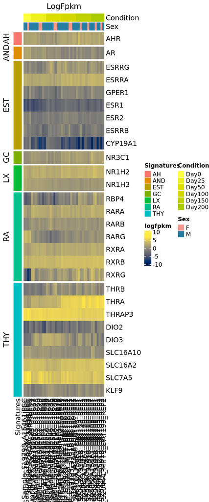

```r
assays(SE_Filt[row.names(SE_Filt) %in% Genes, ])$logfpkm %>% quantile(seq(0,1, by=0.1))
##         0%        10%        20%        30%        40%        50%        60%
## -9.3613016 -2.4701969 -1.3110750 -0.4796018  0.3278364  0.8802159  1.5468896
##        70%        80%        90%       100%
##  2.2579513  2.9700968  4.1701296  6.9090993

ExpCols <- viridisLite::cividis(length(seq(-10, 7, by=0.2)))

sechm(SE_Filt[, sorting], features=Genes, assayName="logfpkm", gaps_row="Signatures", top_annotation = c("Condition", "Sex"), show_rownames = TRUE, left_annotation = "Signatures", sortRowsOn=NULL, cluster_rows=FALSE, show_colnames=TRUE,
      hmcols=ExpCols, breaks=seq(-10, 7, by=0.2), column_title = "LogFpkm")
```

```r
# breaks FALSE to avoid a symmetrical scale
```

#### 7.4 Expression levels: scaled logFpkm

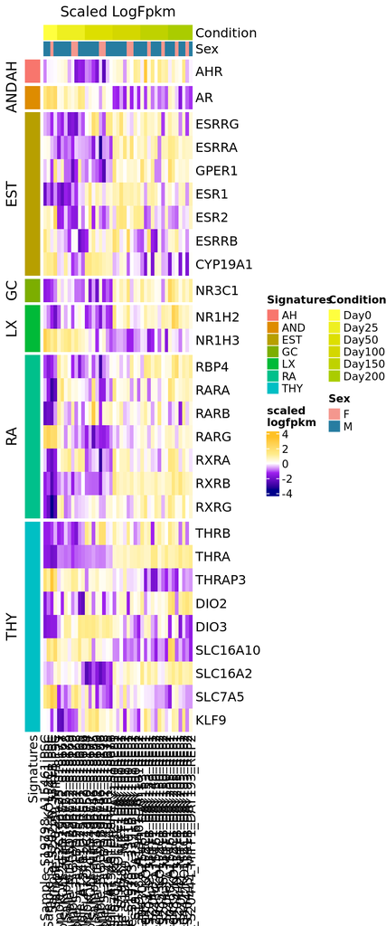

```r
ScaledCols <- c('darkblue', "purple","white","lightgoldenrod1", 'goldenrod1')

sechm::sechm(SE_Filt[, sorting], features=Genes, assayName="logfpkm", gaps_row="Signatures", top_annotation = c("Condition", "Sex"),  show_rownames=TRUE, left_annotation = "Signatures", show_colnames=TRUE, sortRowsOn=NULL, cluster_rows=FALSE, hmcols=ScaledCols, do.scale=TRUE, breaks=0.8, column_title = "Scaled LogFpkm")
```

#### 7.5 Expression levels: scaled logcpm

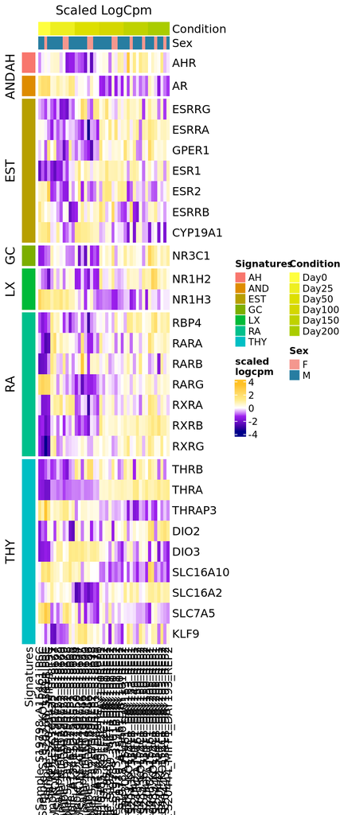

```r
sechm::sechm(SE_Filt[, sorting], features=Genes, assayName="logcpm", gaps_row="Signatures", top_annotation = c("Condition", "Sex"),  show_rownames=TRUE, left_annotation = "Signatures", show_colnames=TRUE, sortRowsOn=NULL, cluster_rows=FALSE, hmcols=ScaledCols, do.scale=TRUE, breaks=0.8, column_title = "Scaled LogCpm")
```

#### 7.6 Expression levels: Log2FC versus Day0

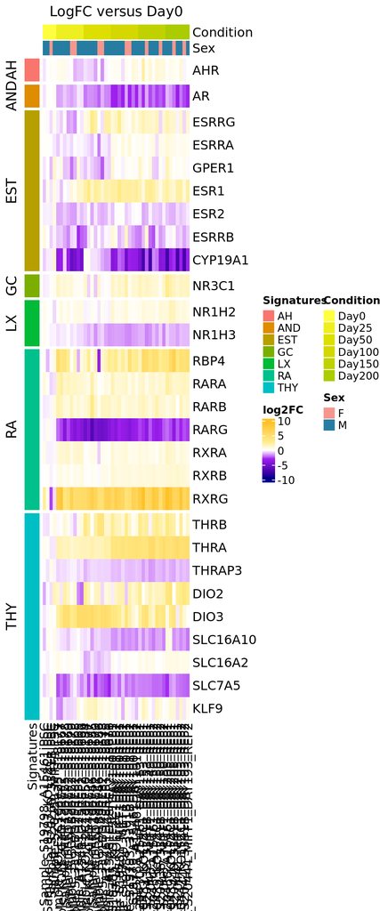

```r
sechm(SE_Filt[, sorting], features=Genes, assayName="log2FC", gaps_row="Signatures", top_annotation = c("Condition", "Sex"), left_annotation = "Signatures", show_colnames=TRUE, sortRowsOn=NULL, cluster_rows=FALSE,
      show_rownames = TRUE, hmcols=ScaledCols,
      do.scale=FALSE, breaks = 0.85, column_title = "LogFC versus Day0")
```

### 8. Lollipops: exploration of receptors

#### 8.1 Preprocessing

```r
Design_sorted <- Design %>% dplyr::arrange(factor(Condition, levels = c("Day0", "Day25", "Day50", "Day100", "Day150", "Day200")))
Design_sorted$Condition <- factor(Design_sorted$Condition, levels = c("Day0", "Day25", "Day50", "Day100", "Day150", "Day200"))
```

##### 8.1.1 Saving LogFkm values for all samples

```r
LogFpkmDF <- assays(SE_Filt[,sorting])$logfpkm
```

##### 8.1.2 Creation of CuratedSig list

CuratedSig list is created:

- LogFpkm by LogFpkmSignature function: stores expression values in logFpkm for signature genes
- LogFpkmMean by SigLogFpkmMean function: calculate mean expression for each gene in each stage

```r
#prepare Design for functions
CuratedSig <- list()
Design_sorted$names <- Design_sorted$InternaUniqueID
# Check for missing genes
GS$GeneName[!(GS$GeneName %in% rownames(LogFpkmDF))]
```

```
## [1] "DIO1"  "THRSP"
```

```r
colnames(GS)[2] <- "Population"
#excluding the missing ones
Genes <- GS$GeneName[(GS$GeneName %in% rownames(LogFpkmDF))]
```

#### 8.2 Expression values for gene signatures

```r
# Retrieval of expression values for gene signatures
CuratedSig$LogFpkm <- LogFpkmSignature(MetaData=Design_sorted, LogFpkmData=LogFpkmDF, GeneSig=Genes)
head(CuratedSig$LogFpkm)
##                InternaUniqueID                         HRID       SampleName
## 1     Sample_S19798_A15461iPSC     Sample_S19798_A15461iPSC     S_A15461iPSC
## 2    Sample_S19797_KOLF2C1iPSC    Sample_S19797_KOLF2C1iPSC    S_KOLF2C1iPSC
## 3      Sample_S20260_3391BiPSC      Sample_S20260_3391BiPSC      S_3391BiPSC
## 4      Sample_S20259_MIFF1iPSC      Sample_S20259_MIFF1iPSC      S_MIFF1iPSC
## 5   Sample_KOLF2C1day25_S18177   Sample_KOLF2C1day25_S18177 S_KOLF2C1D25REP1
## 6 Sample_KOLF2C1D25REP2_S18667 Sample_KOLF2C1D25REP2_S18667 S_KOLF2C1D25REP2
##   Speciment Condition  Group      Line Sex DiffBatch       Seq RNASelection
## 1      IPSC      Day0   IPSC  L_A15461   M         0 PairedEnd     RiboZero
## 2      IPSC      Day0   IPSC L_KOLF2C1   M         0 PairedEnd     RiboZero
## 3      IPSC      Day0   IPSC   L_3391B   F         0 PairedEnd     RiboZero
## 4      IPSC      Day0   IPSC   L_MIFF1   M         0 PairedEnd     RiboZero
## 5  Organoid     Day25 Org_25 L_KOLF2C1   M         1 PairedEnd     RiboZero
## 6  Organoid     Day25 Org_25 L_KOLF2C1   M         2 PairedEnd     RiboZero
##   SeqPlatform    Run                        names       THRB      THRA   THRAP3
## 1     Novaseq 180622     Sample_S19798_A15461iPSC -2.1931085 1.5977961 6.129991
## 2     Novaseq 180622    Sample_S19797_KOLF2C1iPSC -2.2009883 1.4883257 5.837180
## 3     Novaseq 180622      Sample_S20260_3391BiPSC -1.8554995 0.6802578 6.631729
## 4     Novaseq 180622      Sample_S20259_MIFF1iPSC -0.9966187 0.9043768 6.063937
## 5     Novaseq 180201   Sample_KOLF2C1day25_S18177 -2.0723413 2.9438559 5.373216
## 6     Novaseq 180420 Sample_KOLF2C1D25REP2_S18667 -1.8742316 2.8944538 5.559790
##        DIO2       DIO3  SLC16A10  SLC16A2   SLC7A5       KLF9      ESRRG
## 1 -4.875201 -2.7903240 0.2747060 3.812203 5.673317 -0.1483813 -0.0502892
## 2 -3.632907 -2.4336093 1.6034017 3.668992 6.101897 -0.2099453 -0.2796473
## 3 -4.214556 -2.2157610 1.1579555 3.718660 6.909099 -1.2267247 -0.9296575
## 4 -1.789884 -2.2440799 1.8238977 4.132668 6.519561 -0.3337586  0.2361960
## 5 -2.416884 -0.3220758 0.8562001 4.318113 3.695471 -2.2374459 -0.7802904
## 6 -4.132264  0.7504452 0.6531462 3.954587 4.341889 -2.3605386 -1.1177214
##      ESRRA      GPER1      ESR1        ESR2       ESRRB    CYP19A1       AR
## 1 2.661603 -1.3616097 -6.065618 -0.98487209 -0.08942631 -2.8417106 1.400413
## 2 2.707611 -0.9072015 -4.653845 -0.85198271 -0.85279263 -2.3290379 2.015931
## 3 2.331885 -2.0783794 -5.751873 -1.13108063 -1.77821989 -2.5126797 1.712929
## 4 2.191880  0.4128708 -4.393556  0.08782778 -1.11602014 -0.8411801 2.088872
## 5 1.560931 -1.2243860 -5.573497 -2.09730282 -1.94184400 -5.7957463 0.309950
## 6 2.180292 -0.3571294 -6.277148 -2.02593066 -1.83416159 -5.5616470 0.388066
##          RBP4      RARA       RARB      RARG     RXRA     RXRB      RXRG
## 1 -3.19396229 1.9705281 -0.9569565 3.0347948 2.064013 3.006055 -2.584866
## 2 -4.44385171 1.2900800 -0.8097196 3.7099950 1.384433 3.151959 -4.485757
## 3 -3.71250016 0.3480331 -0.9104001 2.9734325 1.190648 2.560231 -7.715392
## 4 -2.66625711 0.7393304  0.1208454 3.1015035 1.488644 2.946460 -5.591418
## 5  1.59554310 2.7886136  1.2190075 0.9593060 2.263009 3.303279  2.478974
## 6 -0.02694891 3.3419877  0.8549062 0.4866657 2.557999 3.459517  3.317292
##        AHR        NR3C1    NR1H2    NR1H3
## 1 1.212590 -0.126158327 2.627867 2.337231
## 2 1.719962  0.005060046 2.387083 1.956165
## 3 1.736231  0.210646760 2.090848 1.568786
## 4 1.756420  0.520267204 1.686202 1.823277
## 5 1.905715  1.508664534 2.257890 1.300398
## 6 1.980878  0.915311385 2.848942 1.513940
```

#### 8.3 Mean expressions across stages

```r
# Calculation of mean expression across stages
CuratedSig$LogFpkmMean <- SigLogFpkmMean(CuratedSig$LogFpkm, StartCol=15, GroupCol='Condition', MetaInfo= GS, Arrange='Population')
## Warning: Using an external vector in selections was deprecated in tidyselect 1.1.0.
## ℹ Please use `all_of()` or `any_of()` instead.
##   # Was:
##   data %>% select(StartCol)
##
##   # Now:
##   data %>% select(all_of(StartCol))
##
## See <https://tidyselect.r-lib.org/reference/faq-external-vector.html>.
## This warning is displayed once every 8 hours.
## Call `lifecycle::last_lifecycle_warnings()` to see where this warning was
## generated.
## `summarise()` has grouped output by 'GeneName'. You can override using the
## `.groups` argument.
CuratedSig$LogFpkmMean
## # A tibble: 168 × 5
## # Groups:   GeneName [28]
##    GeneName Condition Count ExpMean Population
##    <chr>    <fct>     <int>   <dbl> <chr>
##  1 AHR      Day0          4   1.61  AH
##  2 AHR      Day25         8   1.36  AH
##  3 AHR      Day50         8   1.07  AH
##  4 AHR      Day100        8   2.09  AH
##  5 AHR      Day150        8   2.51  AH
##  6 AHR      Day200        7   1.97  AH
##  7 AR       Day0          4   1.80  AND
##  8 AR       Day25         8   0.756 AND
##  9 AR       Day50         8   0.147 AND
## 10 AR       Day100        8  -0.661 AND
## # … with 158 more rows

print(paste('MeanLog2Fpkm Genes', dim(CuratedSig$LogFpkmMean)[1]))
## [1] "MeanLog2Fpkm Genes 168"
print(paste('Min Value', round(min(CuratedSig$LogFpkmMean$ExpMean), 2)))
## [1] "Min Value -6.94"
print(paste('Max Value', round(max(CuratedSig$LogFpkmMean$ExpMean), 2)))
## [1] "Max Value 6.3"
```

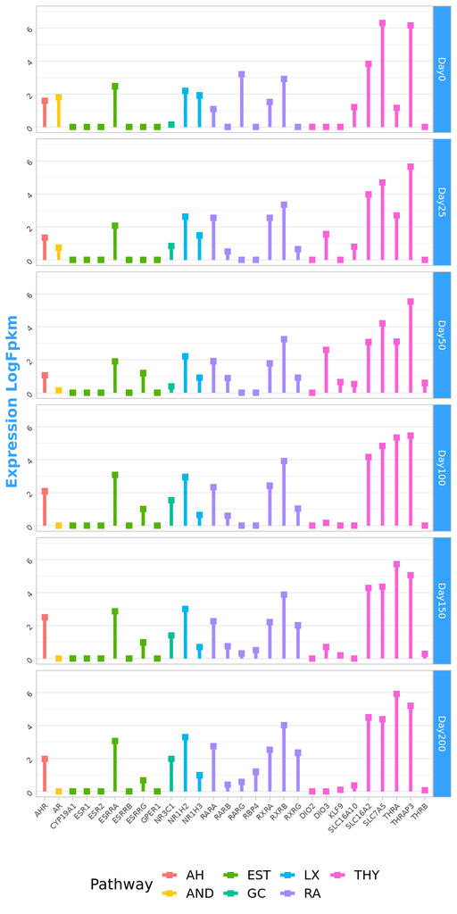

```r
ColVec <- c('DMSO' = '#4D4D4D', 'AH' = '#F8766D', 'AND'= '#fccb17', 'EST' = '#53B400', 'GC' = '#00C094', 'LX' = '#00B6EB', 'RA' = '#A58AFF', 'THY' = '#FB61D7')
#scales::hue_pal()(12)

colnames(CuratedSig$LogFpkmMean)[2] <- "Stage"

CuratedSig$Lolli <- LolliPopCols(Data=CuratedSig$LogFpkmMean, PointSize=2.5,
                                                   SegSize=1.5, yLow=0, yHigh=7, CeilDown=0,
                                                   CeilUp=7, unit='LogFpkm', cols=ColVec,
                                                   Shape=15, GeneSize=7, filterZero=FALSE) + theme(
                                                      legend.text = element_text(size = 12),
                                                      legend.title = element_text(size = 14)
                                                    )+ labs(color = "Pathway")
## Warning: Using `size` aesthetic for lines was deprecated in ggplot2 3.4.0.
## ℹ Please use `linewidth` instead.
## This warning is displayed once every 8 hours.
## Call `lifecycle::last_lifecycle_warnings()` to see where this warning was
## generated.
CuratedSig$Lolli
```

#### 8.4 Delta Log2Fpkm compared to a reference stage: earliest organoid stage (Day 25)

```r
quantile(CuratedSig$LogFpkmMean$ExpMean)
##         0%        25%        50%        75%       100%
## -6.9424978 -0.7615809  0.7517050  2.5135587  6.3009684
```

```r
# reference stage for each dataset
# Retrieval of expression values for gene signatures
CuratedSig$LogFpkmDelta <- DeltaLogFpkmMean(CuratedSig$LogFpkmMean, GroupCol='Stage', DiscardStage="Day0",
                                                             RefStage="SDay25", Arrange='Population', Th=-1.5, Substitute=NA)
CuratedSig$LogFpkmDelta
## # A tibble: 112 × 4
## # Groups:   GeneName [28]
##    GeneName Population Stage             ExpMean
##    <chr>    <chr>      <chr>               <dbl>
##  1 AHR      AH         D2_SDay50_SDay25   -0.291
##  2 AHR      AH         D3_SDay100_SDay25   0.726
##  3 AHR      AH         D4_SDay150_SDay25   1.15
##  4 AHR      AH         D5_SDay200_SDay25   0.607
##  5 AR       AND        D2_SDay50_SDay25   -0.609
##  6 AR       AND        D3_SDay100_SDay25  -1.42
##  7 AR       AND        D4_SDay150_SDay25  -1.10
##  8 AR       AND        D5_SDay200_SDay25  -1.07
##  9 CYP19A1  EST        D2_SDay50_SDay25   NA
## 10 ESR1     EST        D2_SDay50_SDay25   NA
## # … with 102 more rows

print(paste('DeltaLogFpkm Genes', dim(CuratedSig$LogFpkmDelta)[1]))
## [1] "DeltaLogFpkm Genes 112"
print(paste('Min Value', round(min(CuratedSig$LogFpkmDelta$ExpMean, na.rm=T),2)))
## [1] "Min Value -2.39"
print(paste('Max Value', round(max(CuratedSig$LogFpkmDelta$ExpMean, na.rm=T),2)))
## [1] "Max Value 3.22"
```

```r
CuratedSig$LogFpkmDelta$Stage[CuratedSig$LogFpkmDelta$Stage=="D2_SDay50_SDay25"] <- "Day50 vs Day25"
CuratedSig$LogFpkmDelta$Stage[CuratedSig$LogFpkmDelta$Stage=="D3_SDay100_SDay25"] <- "Day100 vs Day25"
CuratedSig$LogFpkmDelta$Stage[CuratedSig$LogFpkmDelta$Stage=="D4_SDay150_SDay25"] <- "Day150 vs Day25"
CuratedSig$LogFpkmDelta$Stage[CuratedSig$LogFpkmDelta$Stage=="D5_SDay200_SDay25"] <- "Day200 vs Day25"

CuratedSig$LogFpkmDelta$Stage <- factor(CuratedSig$LogFpkmDelta$Stage, levels= c("Day50 vs Day25", "Day100 vs Day25", "Day150 vs Day25", "Day200 vs Day25"))
```

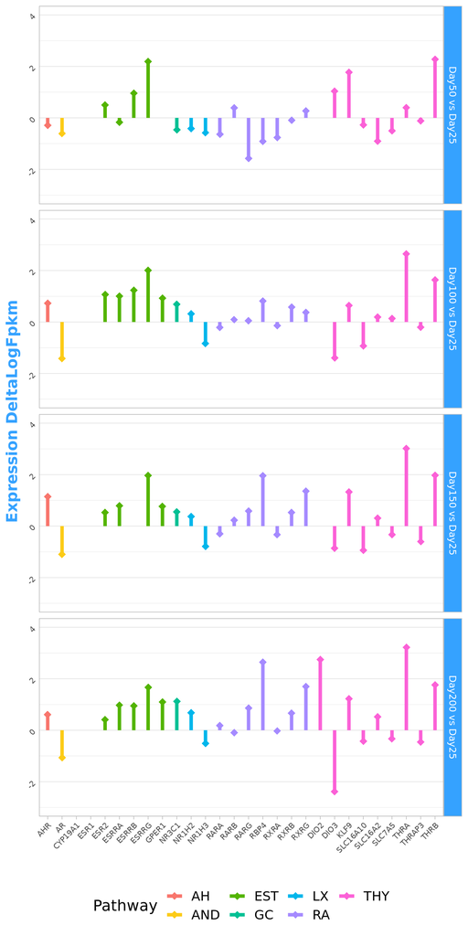

```r
CuratedSig$LolliDelta <- LolliPopCols(CuratedSig$LogFpkmDelta, PointSize=3, SegSize=1.5,
                                            cols=ColVec, yLow=-3, yHigh=4,  CeilUp=4, CeilDown=-3,
                                            unit='DeltaLogFpkm', Shape=18, GeneSize=7, filterZero=FALSE) +
                                                theme(
                                                      legend.text = element_text(size = 12),
                                                      legend.title = element_text(size = 14)
                                                    ) + labs(color = "Pathway")
CuratedSig$LolliDelta
## Warning: Removed 13 rows containing missing values (`geom_point()`).
## Warning: Removed 13 rows containing missing values (`geom_segment()`).
```

#### 8.5 Delta Log2Fpkm compared to iPSC

```r
CuratedSig$LogFpkmDeltaII <- DeltaLogFpkmMean(CuratedSig$LogFpkmMean, GroupCol='Stage', DiscardStage=NULL,
                                                             RefStage="SDay0", Arrange='Population', Th=-1.5, Substitute=NA)
CuratedSig$LogFpkmDeltaII
## # A tibble: 140 × 4
## # Groups:   GeneName [28]
##    GeneName Population Stage            ExpMean
##    <chr>    <chr>      <chr>              <dbl>
##  1 AHR      AH         D2_SDay25_SDay0   -0.246
##  2 AHR      AH         D3_SDay50_SDay0   -0.536
##  3 AHR      AH         D4_SDay100_SDay0   0.480
##  4 AHR      AH         D5_SDay150_SDay0   0.901
##  5 AHR      AH         D6_SDay200_SDay0   0.362
##  6 AR       AND        D2_SDay25_SDay0   -1.05
##  7 AR       AND        D3_SDay50_SDay0   -1.66
##  8 AR       AND        D4_SDay100_SDay0  -2.47
##  9 AR       AND        D5_SDay150_SDay0  -2.15
## 10 AR       AND        D6_SDay200_SDay0  -2.12
## # … with 130 more rows
print(paste('DeltaLogFpkm Genes', dim(CuratedSig$LogFpkmDeltaII)[1]))
## [1] "DeltaLogFpkm Genes 140"
print(paste('Min Value', round(min(CuratedSig$LogFpkmDeltaII$ExpMean, na.rm=T),2)))
## [1] "Min Value -5.05"
print(paste('Max Value', round(max(CuratedSig$LogFpkmDeltaII$ExpMean, na.rm=T),2)))
## [1] "Max Value 7.44"
```

```r
CuratedSig$LogFpkmDeltaII$Stage[CuratedSig$LogFpkmDeltaII$Stage=="D2_SDay25_SDay0"] <- "Day25 vs Day0"
CuratedSig$LogFpkmDeltaII$Stage[CuratedSig$LogFpkmDeltaII$Stage=="D3_SDay50_SDay0"] <- "Day50 vs Day0"
CuratedSig$LogFpkmDeltaII$Stage[CuratedSig$LogFpkmDeltaII$Stage=="D4_SDay100_SDay0"] <- "Day100 vs Day0"
CuratedSig$LogFpkmDeltaII$Stage[CuratedSig$LogFpkmDeltaII$Stage=="D5_SDay150_SDay0"] <- "Day150 vs Day0"
CuratedSig$LogFpkmDeltaII$Stage[CuratedSig$LogFpkmDeltaII$Stage=="D6_SDay200_SDay0"] <- "Day200 vs Day0"

CuratedSig$LogFpkmDeltaII$Stage <- factor(CuratedSig$LogFpkmDeltaII$Stage, levels= c("Day25 vs Day0", "Day50 vs Day0", "Day100 vs Day0", "Day150 vs Day0", "Day200 vs Day0"))
```

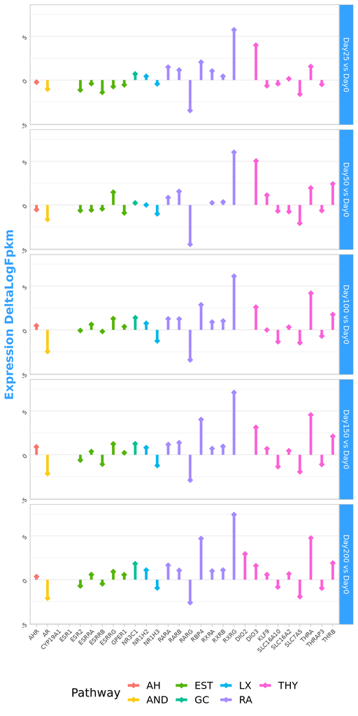

```r
CuratedSig$LolliDeltaII <- LolliPopCols(CuratedSig$LogFpkmDeltaII, PointSize=3, SegSize=1.5,
                                            cols=ColVec, yLow=-4.5, yHigh=8, CeilUp=8, CeilDown=-4.5,
                                            unit='DeltaLogFpkm', Shape=18, GeneSize=7, filterZero=FALSE)+
                                                  theme(
                                                      legend.text = element_text(size = 12),
                                                      legend.title = element_text(size = 14)
                                                    )+ labs(color = "Pathway")
CuratedSig$LolliDeltaII
## Warning: Removed 16 rows containing missing values (`geom_point()`).
## Warning: Removed 16 rows containing missing values (`geom_segment()`).
```

Saving in Pdf

```r
ggsave(plot=CuratedSig$Lolli, filename=paste0(OutputFolder, 'Cheroni_LogFpkm.pdf'), width=5, height=10)
ggsave(plot=CuratedSig$Lolli, filename=paste0(OutputFolder, 'Cheroni_LogFpkm.png'), width=5, height=10)

ggsave(plot=CuratedSig$LolliDelta, filename=paste0(OutputFolder, 'Cheroni_DeltaLogFpkm_vs25.pdf'), width=5, height=10)
## Warning: Removed 13 rows containing missing values (`geom_point()`).
## Warning: Removed 13 rows containing missing values (`geom_segment()`).
ggsave(plot=CuratedSig$LolliDelta, filename=paste0(OutputFolder, 'Cheroni_DeltaLogFpkm_vs25.png'), width=5, height=10)
## Warning: Removed 13 rows containing missing values (`geom_point()`).
## Removed 13 rows containing missing values (`geom_segment()`).
```

### 9. Savings

```r
SessionInfo <- sessionInfo()
Date <- date()
save.image(paste0(OutputFolder, '/', Dataset, 'EndpointsReceptorsExplorationOrganoidsWorkspace.RData'))
```

```r
SessionInfo
```

[output not shown]

```r
Date
```

```
## [1] "Fri Mar 20 13:44:46 2026"
```